# Tree phenology, Part3 phenoFlex model

Ricarda Scholte-Reh

2025-03-04

This logbook will answer the Exercises of the module “Tree phenology analysis in R”. It will start with chapter 3, ends with chapter 35 and will only shortly tell if a chapter is left out (like chapter 17).  
The logbook is split into the following 3 parts, Climate Scenarios (chapter 3-19), PLS regression (chapter 20-28) and the phenoFlex model (chapter 29-35).

This is part 3 about the phenoFlex model.

# Chapter 29

1. Explain the difference between *output validation* and *process validation*.
- Output validation
  - Compares the model’s outputs to real-world observations to assess accuracy
  - The focus is on the end results that the model produces
- Process validation
  - Looks into the internal mechanisms and assumptions of the model
  - The focus is on the model’s processes and if they correctly represent real-world systems.
  - So rather than validating only the model’s results it checks if the path to get the results aligns with reality
2. Explain what a *validity domain* is and why it is important to consider this whenever we want to use our model to forecast something.
- Validity domain

  Defines the boundaries within which the model works in a useful way and delivers reliable results.
- Importance

  Ensures that the model is applied only to situations where it has been validated and prevents misuse.
3. What is *validation for purpose*?

   Assesses if a model is suitable for a specific intended application. It checks if the model meets the requirements and objectives of the intended use. Also the accuracy of the model and its relevance to the specific context are evaluated.
4. How can we ensure that our model is suitable for the predictions we want to make?

   To ensure this there are some steps that need to be followed:
   1. Define the models purpose and clearly outline the specific objectives and applications of the desired model.
   2. Validate your chosen model. For this use both output and process validation to assess accuracy and internal consistency.
   3. Determine the model’s valid range. Identify the conditions under which the model operates reliably.
   4. Do continuous evaluations of the model to ensure its accuracy. Compare the model’s predictions to real-world data and update the model if errors occur.

# Chapter 30 The PhenoFlex Model

1. Parameterize the PhenoFlex model for `Roter Boskoop’ apples.

```r
Boskoop <-
  read_tab("D:/! Ricardas Daten/Studium/Master/03. Semester (WiSe 24-25)/Tree phenology analysis in R/Logbook chapters/Roter_Boskoop_bloom_1958_2019.csv") %>%
  select(Pheno_year, First_bloom) %>%
  mutate(Year = as.numeric(substr(First_bloom, 1, 4)),
         Month = as.numeric(substr(First_bloom, 5, 6)),
         Day = as.numeric(substr(First_bloom, 7, 8))) %>%
  make_JDay() %>%
  select(Pheno_year, JDay) %>%
  rename(Year = Pheno_year,
         pheno = JDay)

hourtemps <-
  read_tab("D:/! Ricardas Daten/Studium/Master/03. Semester (WiSe 24-25)/Tree phenology analysis in R/Logbook chapters/TMaxTMin1958-2019_patched.csv") %>%
  stack_hourly_temps(latitude = 50.6)

par <-   c(40, 190, 0.5, 25, 3372.8,  9900.3, 6319.5, 5.939917e13,  4, 36,  4,  1.60)
upper <- c(41, 200, 1.0, 30, 4000.0, 10000.0, 7000.0, 6.e13, 10, 40, 10, 50.00)
lower <- c(38, 180, 0.1, 0 , 3000.0,  9000.0, 6000.0, 5.e13,  0,  0,  0,  0.05)

SeasonList <- genSeasonList(hourtemps$hourtemps,
                            mrange = c(8, 6),
                            years = c(1959:2019))
```

```r
Fit_res <- phenologyFitter(par.guess = par,
                           modelfn = PhenoFlex_GDHwrapper,
                           bloomJDays = Boskoop$pheno[which(Boskoop$Year > 1957)],
                           SeasonList = SeasonList,
                           lower = lower,
                           upper = upper,
                           control = list(smooth = FALSE,
                                          verbose = FALSE,
                                          maxit = 1000,
                                          nb.stop.improvement = 5))

Boskoop_par <- Fit_res$par

write.csv(Boskoop_par, "D:/! Ricardas Daten/Studium/Master/03. Semester (WiSe 24-25)/Tree phenology analysis in R/Logbook chapters/PhenoFlex_parameters_roter_Boskoop.csv")
```

2. Produce plots of predicted vs. observed bloom dates and distribution of prediction errors.

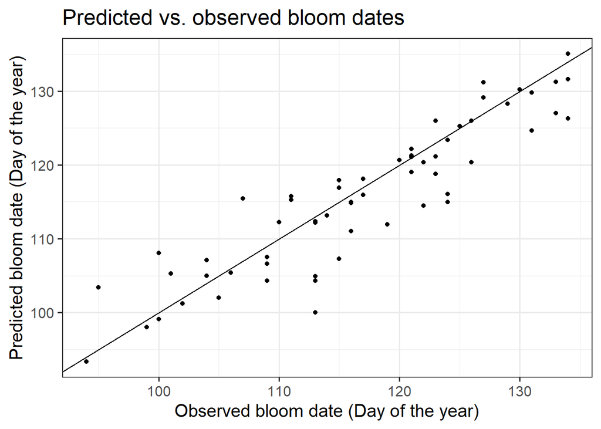

```r
Boskoop_par <- read_tab("D:/! Ricardas Daten/Studium/Master/03. Semester (WiSe 24-25)/Tree phenology analysis in R/Logbook chapters/PhenoFlex_parameters_roter_Boskoop.csv")[,2]

SeasonList <- genSeasonList(hourtemps$hourtemps,
                            mrange = c(8, 6),
                            years = c(1959:2019))

Boskoop_PhenoFlex_predictions <- Boskoop[which(Boskoop$Year > 1958),]

for(y in 1:length(Boskoop_PhenoFlex_predictions$Year))
   Boskoop_PhenoFlex_predictions$predicted[y] <-
    PhenoFlex_GDHwrapper(SeasonList[[y]],
                         Boskoop_par)

Boskoop_PhenoFlex_predictions$Error <-
  Boskoop_PhenoFlex_predictions$predicted -
  Boskoop_PhenoFlex_predictions$pheno

ggplot(Boskoop_PhenoFlex_predictions,
       aes(x = pheno,
           y = predicted)) +
  geom_point() +
  geom_abline(intercept = 0,
              slope = 1) +
  theme_bw(base_size = 15) +
  xlab("Observed bloom date (Day of the year)") +
  ylab("Predicted bloom date (Day of the year)") +
  ggtitle("Predicted vs. observed bloom dates")
```

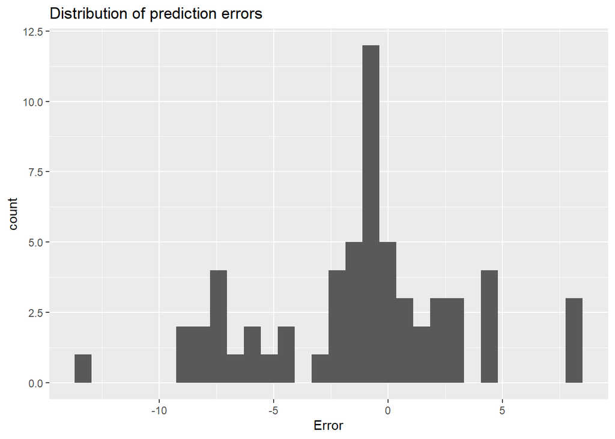

```r
ggplot(Boskoop_PhenoFlex_predictions,
       aes(Error)) +
  geom_histogram() +
  ggtitle("Distribution of prediction errors")
```

3. Compute the model performance metrics RMSEP, mean error and mean absolute error.

```r
RMSEP(Boskoop_PhenoFlex_predictions$predicted,
      Boskoop_PhenoFlex_predictions$pheno)
```

```
## [1] 4.52457
```

```r
mean(Boskoop_PhenoFlex_predictions$Error)
```

```
## [1] -1.23125
```

```r
mean(abs(Boskoop_PhenoFlex_predictions$Error))
```

```
## [1] 3.347917
```

# Chapter 31 The PhenoFlex Model - a second look

1. Make chill and heat response plots for the ‘Roter Boskoop’ PhenoFlex model for the location you did the earlier analyses for.

I really tried to incorporate my own temperature data, but I wasn’t able to fin out how to fix the code to the shorter time span (1990-2019 instead of 1958-2019). Even if I got the bloomJDays andSeasonList to the same length I still got error messages that there are some statements not fully met. So Iswitched back to the CKA temperatures to be able to create the plots correctly.

```r
Boskoop <- read_tab("D:/! Ricardas Daten/Studium/Master/03. Semester (WiSe 24-25)/Tree phenology analysis in R/Logbook chapters/Roter_Boskoop_bloom_1958_2019.csv") %>%
  select(Pheno_year, First_bloom) %>%
  mutate(Year = as.numeric(substr(First_bloom, 1, 4)),
         Month = as.numeric(substr(First_bloom, 5, 6)),
         Day = as.numeric(substr(First_bloom, 7, 8))) %>%
  make_JDay() %>%
  select(Pheno_year, JDay) %>%
  rename(Year = Pheno_year,
         pheno = JDay)

temp_data <- read.csv("D:/! Ricardas Daten/Studium/Master/03. Semester (WiSe 24-25)/Tree phenology analysis in R/Logbook chapters/TMaxTMin1958-2019_patched.csv") %>% stack_hourly_temps(latitude = 50.6)

par <-   c(40, 190, 0.5, 25, 3372.8,  9900.3, 6319.5, 5.939917e13,  4, 36,  4,  1.60)
upper <- c(41, 200, 1.0, 30, 4000.0, 10000.0, 7000.0, 6.e13, 10, 40, 10, 50.00)
lower <- c(38, 180, 0.1, 0 , 3000.0,  9000.0, 6000.0, 5.e13,  0,  0,  0,  0.05)

SeasonList <- genSeasonList(temp_data$temp_data,
                            mrange = c(8, 6),
                            years = c(1959:2019))

Fit_res <- phenologyFitter(par.guess = par,
                           modelfn = PhenoFlex_GDHwrapper,
                           bloomJDays = Boskoop$pheno[which(Boskoop$Year > 1957)],
                           SeasonList = SeasonList,
                           lower = lower,
                           upper = upper,
                           control = list(smooth = FALSE,
                                          verbose = FALSE,
                                          maxit = 1000,
                                          nb.stop.improvement = 5))

Boskoop_par <- Fit_res$par

write.csv(Boskoop_par, "D:/! Ricardas Daten/Studium/Master/03. Semester (WiSe 24-25)/Tree phenology analysis in R/Logbook chapters/PhenoFlex_parameters_roter_Boskoop.csv")
```

```r
apply_const_temp <-
  function(temp, A0, A1, E0, E1, Tf, slope, portions = 1200, deg_celsius = TRUE)
    {
  temp_vector <- rep(temp,
                     times = portions)
  res <- chillR::DynModel_driver(temp = temp_vector,
                                 A0 = A0,
                                 A1 = A1,
                                 E0 = E0,
                                 E1 = E1,
                                 Tf = Tf,
                                 slope = slope,
                                 deg_celsius = deg_celsius)
  return(res$y[length(res$y)])
}

gen_bell <- function(par,
                     temp_values = seq(-5, 20, 0.1)) {
  E0 <- par[5]
  E1 <- par[6]
  A0 <- par[7]
  A1 <- par[8]
  Tf <- par[9]
  slope <- par[12]

  y <- c()
  for(i in seq_along(temp_values)) {
    y[i] <- apply_const_temp(temp = temp_values[i],
                             A0 = A0,
                             A1 = A1,
                             E0 = E0,
                             E1 = E1,
                             Tf = Tf,
                             slope = slope)
  }
  return(invisible(y))
}

GDH_response <- function(T, par)
  {Tb <- par[11]
   Tu <- par[4]
   Tc <- par[10]
   GDH_weight <- rep(0, length(T))
   GDH_weight[which(T >= Tb & T <= Tu)] <-
     1/2 * (1 + cos(pi + pi * (T[which(T >= Tb & T <= Tu)] - Tb)/(Tu - Tb)))
   GDH_weight[which(T > Tu & T <= Tc)] <-
     (1 + cos(pi/2 + pi/2 * (T[which(T >  Tu & T <= Tc)] -Tu)/(Tc - Tu)))
  return(GDH_weight)
}
```

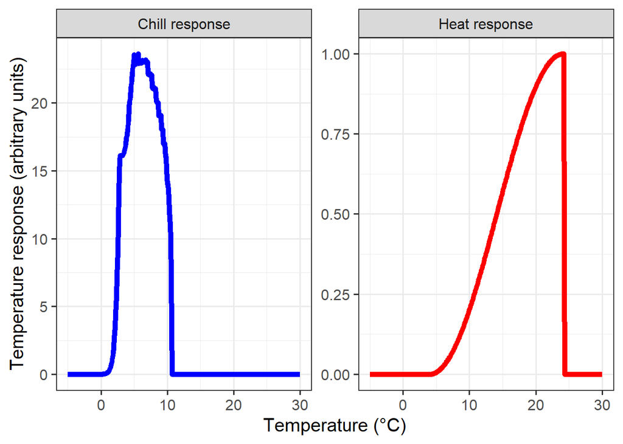

```r
Boskoop <- read_tab("D:/! Ricardas Daten/Studium/Master/03. Semester (WiSe 24-25)/Tree phenology analysis in R/Logbook chapters/PhenoFlex_parameters_roter_Boskoop.csv")[,2]

temp_values = seq(-5, 30, 0.1)

temp_response <- data.frame(Temperature = temp_values,
                            Chill_response = gen_bell(Boskoop,
                                                      temp_values),
                            Heat_response = GDH_response(temp_values,
                                                         Boskoop))

pivoted_response <- pivot_longer(temp_response,
                                 c(Chill_response,
                                   Heat_response))

ggplot(pivoted_response,
       aes(x = Temperature,
           y = value)) +
  geom_line(linewidth = 2,
            aes(col = name)) +
  ylab("Temperature response (arbitrary units)") +
  xlab("Temperature (°C)") +
  facet_wrap(vars(name),
             scales = "free",
             labeller =
               labeller(name = c(Chill_response = c("Chill response"),
                                     Heat_response = c("Heat response")))) +
  scale_color_manual(values = c("Chill_response" = "blue",
                                "Heat_response" = "red")) +
  theme_bw(base_size = 15) +
  theme(legend.position = "none")
```

# Chapter 32 Can we improve the performance of PhenoFlex?

1. What was the objective of this work?

   The study aimed to enhance the performance of the PhenoFlex model by refining its calibration process.
2. What was the main conclusion?

   That the PhenoFlex model’s performance improved when using a calibration approach that incorporated the standard deviation and the mean absolute error of phenological dates.
3. What experiments could we conduct to test the hypothesis that emerged at the end of the conclusion?
   - Cross-validation
     - Apply the model to diverse datasets (different geographic regions and spiecies) to test the robustness and generalizability of the PhenoFlex Model.
     - Use the new data to test the calibrations that were done with the already present data.
   - Comparative analysis
     - Compare the predictive accuracy of the PhenoFlex model calibrated with the combined approach against models calibrated with only one of the error metrics to evaluate the performance differences.
   - Sensitivity analysis
     - Investigate how variations in weighting between standard deviation and mean absolute error during calibration affect the model’s predictions to determine optimal calibration settings.
   - Longitudinal studies
     - Monitor the model’s predictive performance over multiple years to ensure that the improved calibration method maintains its accuracy over time.

# Chapter 33 Frost risk analysis

1. Illustrate the development of the bloom period over the duration of the weather record. Use multiple ways to show this - feel free to be creative.

```r
CKA_Boskoop <- read_tab("D:/! Ricardas Daten/Studium/Master/03. Semester (WiSe 24-25)/Tree phenology analysis in R/Logbook chapters/Roter_Boskoop_bloom_1958_2019.csv")

CKA_weather <- read_tab("D:/! Ricardas Daten/Studium/Master/03. Semester (WiSe 24-25)/Tree phenology analysis in R/Logbook chapters/TMaxTMin1958-2019_patched.csv")

CKA_Boskoop <-
  CKA_Boskoop %>%
  pivot_longer(cols = "First_bloom":"Last_bloom",
               names_to = "variable",
               values_to="YEARMODA") %>%
  mutate(Year = as.numeric(substr(YEARMODA, 1, 4)),
         Month = as.numeric(substr(YEARMODA, 5, 6)),
         Day = as.numeric(substr(YEARMODA, 7, 8))) %>%
  make_JDay()
```

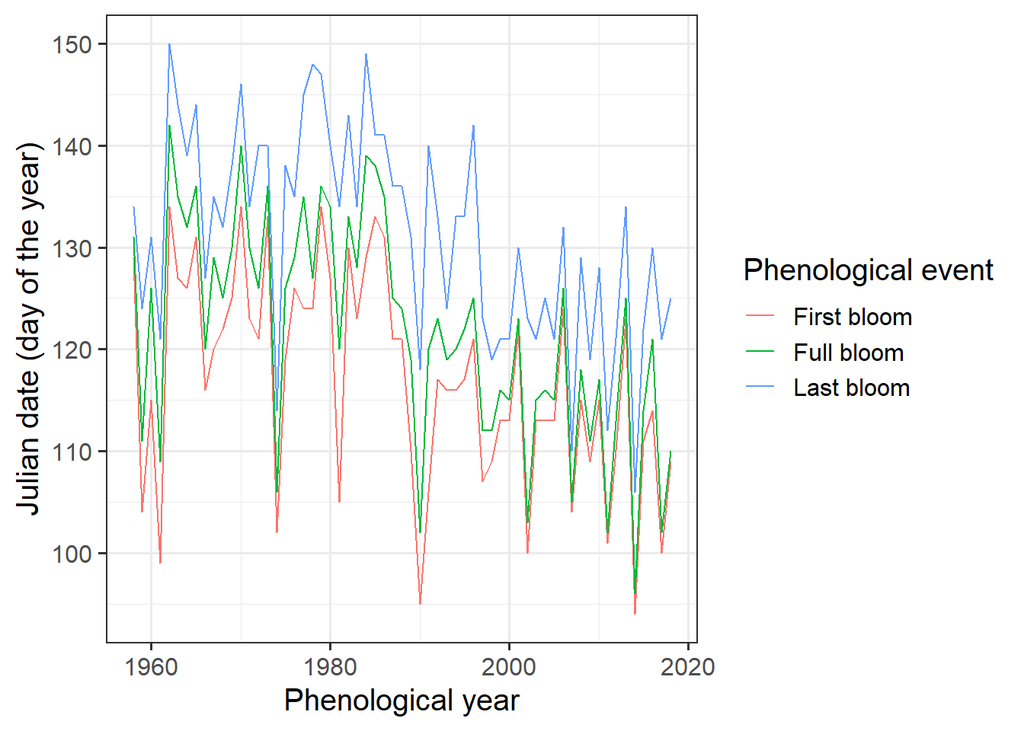

```r
ggplot(data = CKA_Boskoop,
       aes(Pheno_year,
           JDay,
           col = variable)) +
  geom_line() +
  theme_bw(base_size = 15) +
  scale_color_discrete(
    name = "Phenological event",
    labels = c("First bloom",
               "Full bloom",
               "Last bloom")) +
  xlab("Phenological year") +
  ylab("Julian date (day of the year)")
```

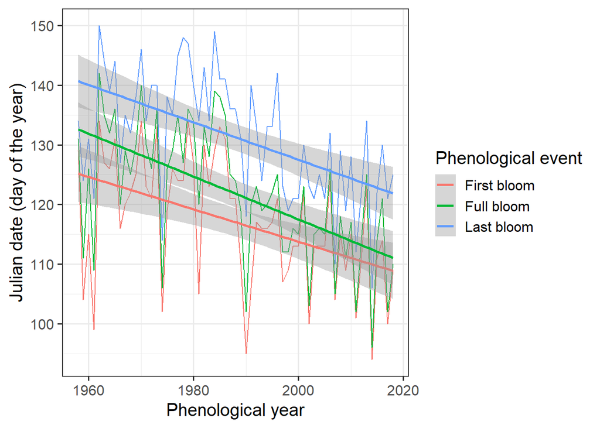

```r
ggplot(data = CKA_Boskoop,
       aes(Pheno_year,
           JDay,
           col = variable)) +
  geom_line() +
  theme_bw(base_size = 15) +
  scale_color_discrete(name = "Phenological event",
                       labels = c("First bloom",
                                  "Full bloom",
                                  "Last bloom")) +
  xlab("Phenological year") +
  ylab("Julian date (day of the year)") +
  geom_smooth(method = "lm")
```

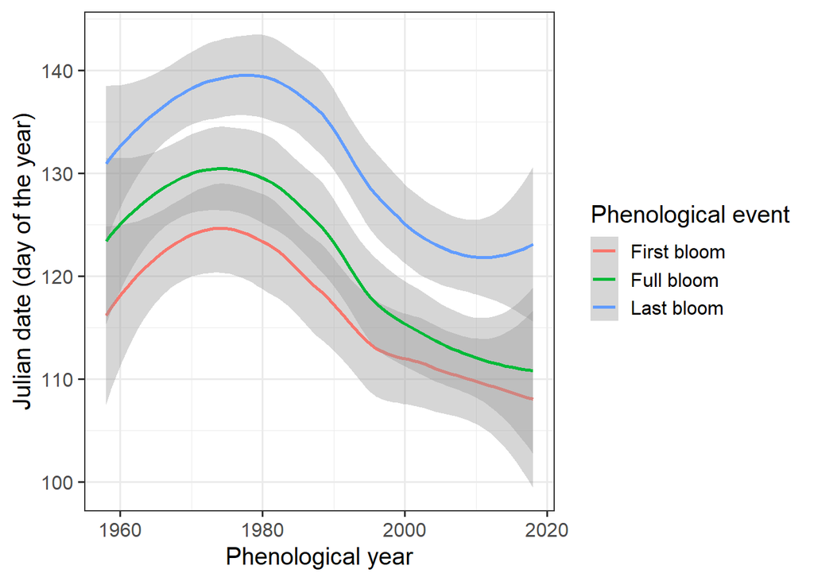

```r
ggplot(data=CKA_Boskoop,aes(Pheno_year,JDay,col=variable)) +
  geom_smooth() +
  theme_bw(base_size=15) +
  scale_color_discrete(
    name = "Phenological event",
    labels = c("First bloom", "Full bloom", "Last bloom")) +
  xlab("Phenological year") +
  ylab("Julian date (day of the year)")
```

2. Evaluate the occurrence of frost events at Klein-Altendorf since 1958. Illustrate this in a plot.

```r
require(Kendall)
Kendall_first <-
  Kendall(x = CKA_Boskoop$Pheno_year[
            which(CKA_Boskoop$variable == "First_bloom")],
          y = CKA_Boskoop$JDay[
            which(CKA_Boskoop$variable == "First_bloom")])

Kendall_full <-
  Kendall(x = CKA_Boskoop$Pheno_year[
            which(CKA_Boskoop$variable == "Full_bloom")],
          y = CKA_Boskoop$JDay[
            which(CKA_Boskoop$variable == "Full_bloom")])

Kendall_last <-
  Kendall(x = CKA_Boskoop$Pheno_year[
            which(CKA_Boskoop$variable == "Last_bloom")],
          y = CKA_Boskoop$JDay[
            which(CKA_Boskoop$variable == "Last_bloom")])

Kendall_first
```

```
## tau = -0.35, 2-sided pvalue =8.4584e-05
```

```r
Kendall_full
```

```
## tau = -0.447, 2-sided pvalue =4.6775e-07
```

```r
Kendall_last
```

```
## tau = -0.38, 2-sided pvalue =1.9136e-05
```

The p-values are all smaller than 0.05, so it is pretty clear that there is a trend.

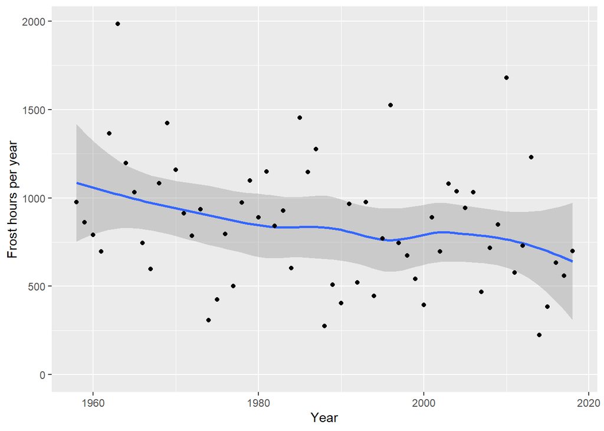

```r
frost_df = data.frame(
  lower = c(-1000, 0),
  upper = c(0, 1000),
  weight = c(1, 0))

frost_model <- function(x) step_model(x,
                                      frost_df)

hourly <- stack_hourly_temps(CKA_weather,
                             latitude = 50.625)

frost <- tempResponse(hourly,
                      models = c(frost = frost_model))

ggplot(frost,
       aes(End_year,
           frost)) +
  geom_smooth() +
  geom_point() +
  ylim(c(0, NA)) +
  ylab("Frost hours per year") +
  xlab("Year")
```

3. Produce an illustration of the relationship between spring frost events and the bloom period of ‘Roter Boskoop’.

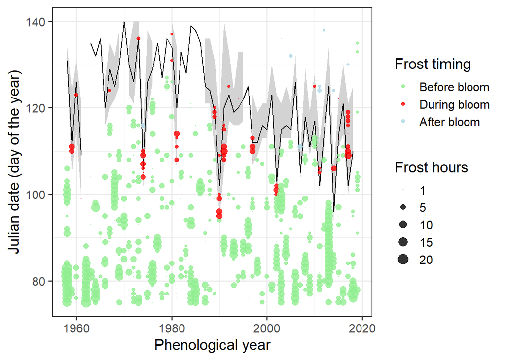

```r
frost_model_no_summ <-
  function(x) step_model(x,
                         frost_df,
                         summ=FALSE)

hourly$hourtemps[, "frost"] <- frost_model_no_summ(hourly$hourtemps$Temp)

Daily_frost_hours <- aggregate(hourly$hourtemps$frost,
                               by = list(hourly$hourtemps$YEARMODA),
                               FUN = sum)

Daily_frost <- make_JDay(CKA_weather)

Daily_frost[, "Frost_hours"] <- Daily_frost_hours$x

Daily_frost$Frost_hours[which(Daily_frost$Frost_hours == 0)] <- NA

Ribbon_Boskoop <-
  CKA_Boskoop %>%
  select(Pheno_year, variable, JDay) %>%
  pivot_wider(names_from = "variable", values_from = "JDay")

lookup_dates <- Ribbon_Boskoop

row.names(lookup_dates) <- lookup_dates$Pheno_year

Daily_frost[, "First_bloom"]<-
  lookup_dates[as.character(Daily_frost$Year),
               "First_bloom"]

Daily_frost[, "Last_bloom"]<-
  lookup_dates[as.character(Daily_frost$Year),
               "Last_bloom"]

Daily_frost[which(!is.na(Daily_frost$Frost_hours)),
            "Bloom_frost"] <-
  "Before bloom"

Daily_frost[which(Daily_frost$JDay >= Daily_frost$First_bloom),
            "Bloom_frost"]<-
  "During bloom"

Daily_frost[which(Daily_frost$JDay > Daily_frost$Last_bloom),
            "Bloom_frost"]<-
  "After bloom"

Daily_frost[which(Daily_frost$JDay > 180),
            "Bloom_frost"]<-
  "Before bloom"

ggplot(data = Ribbon_Boskoop,
       aes(Pheno_year)) +
  geom_ribbon(aes(ymin = First_bloom,
                  ymax = Last_bloom),
              fill = "light gray") +
  geom_line(aes(y = Full_bloom)) +
  theme_bw(base_size = 15) +
  xlab("Phenological year") +
  ylab("Julian date (day of the year)") +
  geom_point(data = Daily_frost,
             aes(Year,
                 JDay,
                 size = Frost_hours,
                 col = Bloom_frost),
             alpha = 0.8) +
  scale_size(range = c(0, 5),
             breaks = c(1, 5, 10, 15, 20),
             labels = c("1", "5", "10", "15", "20"),
             name = "Frost hours") +
  scale_color_manual(
    breaks = c("Before bloom",
               "During bloom",
               "After bloom"),
    values = c("light green",
               "red",
               "light blue"),
    name = "Frost timing") +
  theme_bw(base_size = 15) +
  ylim(c(75, 140))
```

4. Evaluate how the risk of spring frost for this cultivar has changed over time. Has there been a significant trend?

   In the viewed period is a trend visible that shows earlier bloom dates, which could increase the risk of frost damage. However, there is no higher greater frost damage risk visible in the data.

# Chapter 34 A robust method to estimate future frost risks (?)

There are no tasks for this chapter.

# Chapter 35 Major concepts

There are no tasks for this chapter.